# practical_exercise_1, Methods 3, 2021, autumn semester

Louise Brix Pilegaard Hansen

20/9/2021

## Dataset mtcars

Let’s look at the “mtcars” data:

[, 1] mpg Miles/(US) gallon  
[, 2] cyl Number of cylinders  
[, 3] disp Displacement (cu.in.)  
[, 4] hp Gross horsepower  
[, 5] drat Rear axle ratio  
[, 6] wt Weight (lb/1000)  
[, 7] qsec 1/4 mile time  
[, 8] vs V/S  
[, 9] am Transmission (0 = automatic, 1 = manual)  
[,10] gear Number of forward gears  
[,11] carb Number of carburetors

## Miles per gallon and weight

We can do a scatter plot, and it looks like there is some relation between fuel usage and the weight of cars. Let’s investigate this further

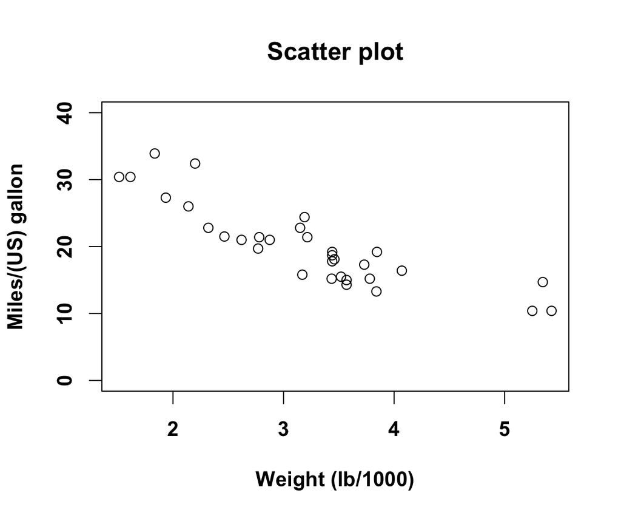

```r
par(font.lab=2, font.axis=2, cex=1.2)
plot(mpg ~ wt, data=mtcars, xlab='Weight (lb/1000)', ylab='Miles/(US) gallon',
     main='Scatter plot', ylim=c(0, 40))
```

# Exercises and objectives

The objectives of today’s exercises are:  
1) To remind you of the (general) linear model, and how we can use it to make models in R  
2) To make some informal model comparisons  
3) To estimate models based on binomially distributed data

If you would like to read more about a given function, just prepend the function with a question mark, e.g.

```r
?lm
```

REMEMBER: In your report, make sure to include code that can reproduce the answers requested in the exercises below

## Exercise 1

The general linear model: $Y = X \beta + \epsilon$:  
Do a linear regression, expressing fuel usage as a function of weight using the function **lm**

```r
data(mtcars)
model <- lm(mpg ~ wt, data=mtcars)
summary(model)
```

```
##
## Call:
## lm(formula = mpg ~ wt, data = mtcars)
##
## Residuals:
##     Min      1Q  Median      3Q     Max
## -4.5432 -2.3647 -0.1252  1.4096  6.8727
##
## Coefficients:
##             Estimate Std. Error t value Pr(>|t|)
## (Intercept)  37.2851     1.8776  19.858  < 2e-16 ***
## wt           -5.3445     0.5591  -9.559 1.29e-10 ***
## ---
## Signif. codes:  0 '***' 0.001 '**' 0.01 '*' 0.05 '.' 0.1 ' ' 1
##
## Residual standard error: 3.046 on 30 degrees of freedom
## Multiple R-squared:  0.7528, Adjusted R-squared:  0.7446
## F-statistic: 91.38 on 1 and 30 DF,  p-value: 1.294e-10
```

1. extract $\hat{\beta}$, $Y$, $\hat{Y}$, $X$ and $\epsilon$ from **model** (hint: have a look at the function **model.matrix**)

```r
beta_hat <- model$coefficients
Y_hat <- beta_hat[1] + mtcars$wt*beta_hat[2]
Y <- mtcars$mpg
X <- mtcars$wt
error <- model$residuals
```

1. create a plot that illustrates $Y$ and $\hat{Y}$ (if you are feeling ambitious, also include $\epsilon$ (hint: you can use the function **arrows**))

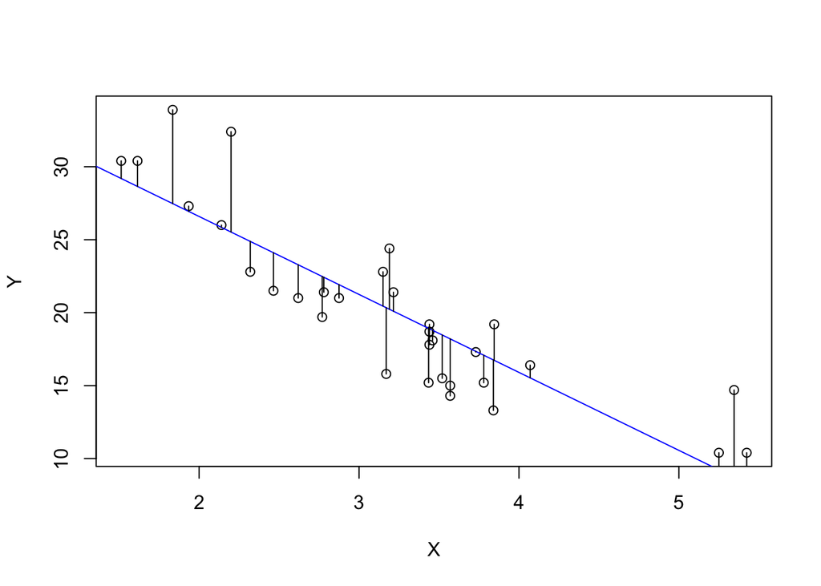

```r
plot(X, Y)
abline(a = beta_hat[1], b = beta_hat[2], col = "blue")
arrows(x0=X, y0 = Y, y1 = Y_hat, length = 0, code = 2, angle = 0)
```

**- The blue line shows predicted values of Y (Y-hat) whereas the dots shows the observed values of Y. The lines are the error**

2. estimate $\beta$ for a quadratic model ($y = {\beta}_{2} x^2 + {\beta}_{1} x + {\beta}_{0}$) using ordinary least squares *without* using **lm**; $\hat{\beta} = {({X}^{T} X)}^{-1} {X}^{T} Y$ (hint: add a third column to $X$ from step 1)

```r
#creating a design matrix, where the first column contains 1's, the second contains the wt variable from mtcars, and the third columns is the wt-variable squared

n <- 32
const <- rep(1,n)
design_matrix <- cbind(const, mtcars$wt, (mtcars$wt)^2)

#using the OLS equation to calculate our beta values
beta_ols <- solve(t(design_matrix)%*%design_matrix)%*%t(design_matrix)%*%Y
beta_ols
```

```
##             [,1]
## const  49.930811
##       -13.380337
##         1.171087
```

3. compare your acquired $\hat{\beta}$ with the output of the corresponding quadratic model created using **lm** (hint: use the function **I**, see details under help and the sub-section formula operators here: https://www.datacamp.com/community/tutorials/r-formula-tutorial)

```r
design_matrix <- cbind(design_matrix, mtcars$mpg)
colnames(design_matrix) <- c("const", "wt", "wt_sqr", "mpg")

design_matrix <- data.frame(design_matrix)

lm_model <- lm(mpg ~ wt + wt_sqr, data = design_matrix)
summary(lm_model)
```

```
##
## Call:
## lm(formula = mpg ~ wt + wt_sqr, data = design_matrix)
##
## Residuals:
##    Min     1Q Median     3Q    Max
## -3.483 -1.998 -0.773  1.462  6.238
##
## Coefficients:
##             Estimate Std. Error t value Pr(>|t|)
## (Intercept)  49.9308     4.2113  11.856 1.21e-12 ***
## wt          -13.3803     2.5140  -5.322 1.04e-05 ***
## wt_sqr        1.1711     0.3594   3.258  0.00286 **
## ---
## Signif. codes:  0 '***' 0.001 '**' 0.01 '*' 0.05 '.' 0.1 ' ' 1
##
## Residual standard error: 2.651 on 29 degrees of freedom
## Multiple R-squared:  0.8191, Adjusted R-squared:  0.8066
## F-statistic: 65.64 on 2 and 29 DF,  p-value: 1.715e-11
```

**- the values are the same for the manual OLS estimator and the lm function**

1. create a plot that illustrates $Y$ and $\hat{Y}$ (if you are feeling ambitious, also include $\epsilon$ (hint: you can use the function **arrows**))

```r
design_matrix <- as.matrix(design_matrix)
yhat <- design_matrix[,1:3]%*%beta_ols
```

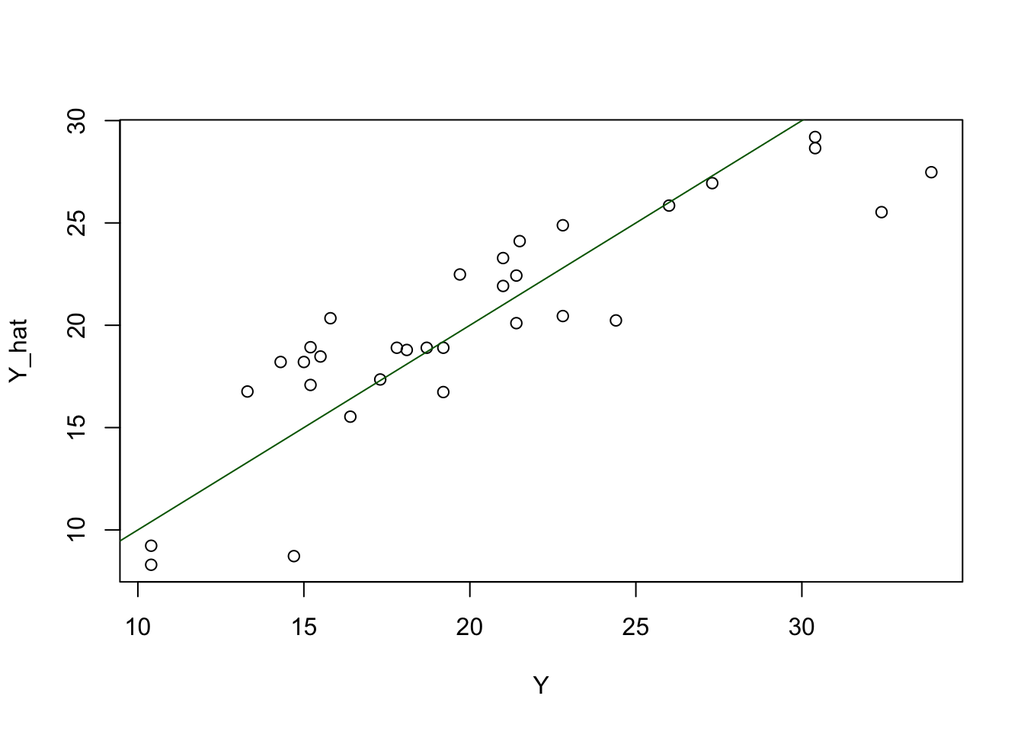

```r
#linear plot
plot(Y, Y_hat)
abline(a = 0, b = 1, col = 'darkgreen')
```

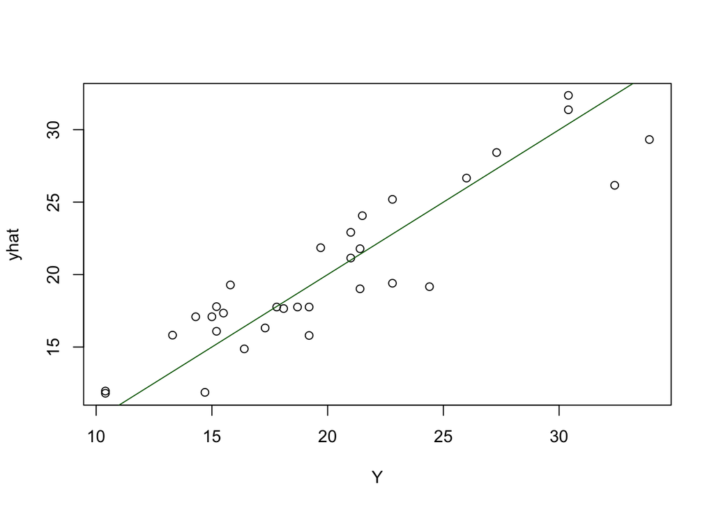

```r
#quadratic plot
plot(Y, yhat)
abline(a = 0, b = 1, col = 'darkgreen')
```

## Exercise 2

Compare the plotted quadratic fit to the linear fit

1. which seems better?  
   **- the quadratic plot seems to fit the data a bit better that the linear fit. The errors are distributed more evenly across the entire model, whereas for the linear model, some of the errors are more extreme than others.**
2. calculate the sum of squared errors, (show the calculation based on $\epsilon$). Which fit has the lower sum?

```r
# linear model
sum((Y - Y_hat)^2)
```

```
## [1] 278.3219
```

```r
# quadratic fit
sum((Y - yhat)^2)
```

```
## [1] 203.7454
```

**- The quadratic fit has the lower sum of squared errors**

3. now make a cubic fit ($y = {\beta}_{3} x^3 + {\beta}_{2} x^2 + {\beta}_{1} x + {\beta}_{0}$) and compare it to the quadratic fit

```r
cub_df <- cbind(design_matrix[,1:3], (mtcars$wt)^3)
colnames(cub_df) <- c("const", "wt", "wt_sqr", "wt_cub")
cub_df <- cbind(cub_df, mtcars$mpg)
colnames(cub_df) <- c("const", "wt", "wt_sqr", "wt_cub", "mpg")

cub_df <- data.frame(cub_df)

cubic_model <- lm(mpg ~ wt + wt_sqr + wt_cub, data = cub_df)
summary(cubic_model)
```

```
##
## Call:
## lm(formula = mpg ~ wt + wt_sqr + wt_cub, data = cub_df)
##
## Residuals:
##    Min     1Q Median     3Q    Max
## -3.506 -1.999 -0.768  1.490  6.188
##
## Coefficients:
##              Estimate Std. Error t value Pr(>|t|)
## (Intercept)  48.40370   15.58379   3.106  0.00431 **
## wt          -11.82598   15.46346  -0.765  0.45081
## wt_sqr        0.68938    4.74034   0.145  0.88541
## wt_cub        0.04594    0.45070   0.102  0.91954
## ---
## Signif. codes:  0 '***' 0.001 '**' 0.01 '*' 0.05 '.' 0.1 ' ' 1
##
## Residual standard error: 2.697 on 28 degrees of freedom
## Multiple R-squared:  0.8191, Adjusted R-squared:  0.7997
## F-statistic: 42.27 on 3 and 28 DF,  p-value: 1.585e-10
```

```r
cubic_betahat <- cubic_model$coefficients
```

1. create a plot that illustrates $Y$ and $\hat{Y}$ for both the cubic and the quadratic fits (plot them in the same plot)

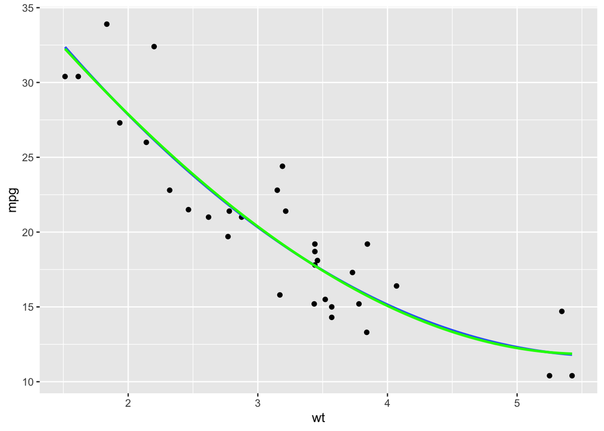

```r
both_plot <- ggplot(mtcars, aes(x = wt, y = mpg))+
  geom_point()+
  stat_smooth(method = "lm", formula = y ~ x + I(x^2), size = 1, se = FALSE)+
  stat_smooth(method = "lm", formula = y ~ x + I(x^2) + I(x^3), size = 1, color = "green", se = FALSE)
both_plot
```

**- Blue line shows quadratic fit, green line shows cubic.**

2. compare the sum of squared errors

```r
cub_df <- as.matrix(cub_df)

#calculating the y-hats for the cubic model
cubic_yhat <- cub_df[,1:4]%*%cubic_betahat

#comparing the quadratic fit and the cubic fit

# quadratic model
sum((Y - yhat)^2)
```

```
## [1] 203.7454
```

```r
# cubic fit
sum((Y - cubic_yhat)^2)
```

```
## [1] 203.6699
```

**There is not very big difference - the cubic fit has a slightly smaller sum of squared errors.**

3. what’s the estimated value of the “cubic” (${\beta}_3$) parameter? Comment on this!

```r
cubic_betahat[4]
```

```
##     wt_cub
## 0.04593618
```

**- The estimated value of the “cubic” parameter is 0.0459, which is quite small. It doesn’t add much to our model.**

4. bonus question: which summary statistic is the fitted value (*Intercept* or ${\beta}_0$ in $y = {\beta}_0$) below identical to?

```
##
## Call:
## lm(formula = mpg ~ 1, data = mtcars)
##
## Coefficients:
## (Intercept)
##       20.09
```

```
## [1] 20.09062
```

**It’s identical to the mean, since making a regression with only an intercept is the same as taking the mean of the dependent variable, as the slope is 0.**

## Exercise 3

Doing a logistic regression - estimating the probability that a car has automatic transmission (0) or manual transmission (1) based on its weight

```r
logistic.model <- glm(am ~ wt, data=mtcars, family='binomial')
summary(logistic.model)
```

```
##
## Call:
## glm(formula = am ~ wt, family = "binomial", data = mtcars)
##
## Deviance Residuals:
##      Min        1Q    Median        3Q       Max
## -2.11400  -0.53738  -0.08811   0.26055   2.19931
##
## Coefficients:
##             Estimate Std. Error z value Pr(>|z|)
## (Intercept)   12.040      4.510   2.670  0.00759 **
## wt            -4.024      1.436  -2.801  0.00509 **
## ---
## Signif. codes:  0 '***' 0.001 '**' 0.01 '*' 0.05 '.' 0.1 ' ' 1
##
## (Dispersion parameter for binomial family taken to be 1)
##
##     Null deviance: 43.230  on 31  degrees of freedom
## Residual deviance: 19.176  on 30  degrees of freedom
## AIC: 23.176
##
## Number of Fisher Scoring iterations: 6
```

Probabilities live on the range $(0, 1)$ - using the so-called logit function as a “link-function” we can map these onto the range $(-\infty, \infty)$, i.e. the real numbers.

What we model in this case is: $Pr(y = 1) = logit^{-1}(X \beta)$, i.e. the probability of a car having manual transmission, given its weight. $X \beta$ is called the linear predictor; compare with $Y = X \beta + \epsilon$ It is helpful to define the logit function and its inverse function for the following:

```r
logit <-     function(x) log(x / (1 - x))
inv.logit <- function(x) exp(x) / (1 + exp(x))
```

1. plot the fitted values for **logistic.model**:

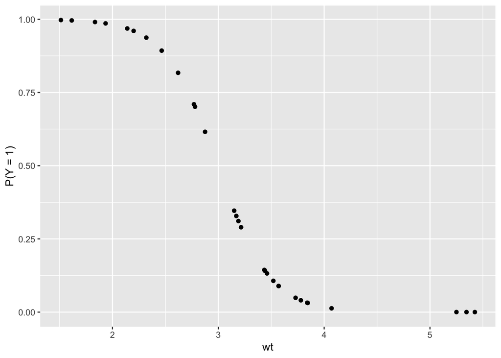

```r
yhat_logistic <- inv.logit(predict(logistic.model))
logistic_df <- data.frame(cbind(mtcars$am, mtcars$wt, yhat_logistic))
colnames(logistic_df) <- c("am", "wt", "yhat_logistic")

ggplot(logistic_df, aes(x=wt, y=yhat_logistic))+
  geom_point()+
  xlab("wt")+
  ylab("P(Y = 1)")
```

1. what is the relation between the **linear.predictors** and the **fitted_values** of the **logistic.model** object?

The relationship between the linear predictors and the fitted values are not linear. This is why we can’t interpret the model summary the same way as for a linear regression. This also means that the difference in y for each increment of x is **not** constant, as it is for a linear regression. This means that the estimates are hard to interpret.

The estimates on their own are hard to interpret since the relationship between the independent variables and the dependent variables are not linear, and the estimates are on the log-scale. We can use their sign and size, but the numbers on their own are hard to interpret. Thus, we must use the inv.logit function in order to interpret them.

The fitted values predicted by our model are also hard to interpret on their own, and can therefore be transformed by the inv.logit function to be converted into probabilities, which are more easily interpreted. After the inv.logit transformation, the fitted values now express the probability of a car having a manual gear (P(Y = 1)) given the weight of the car.

2. plot the logistic function, you’ve estimated based on your $\hat{\beta}$, (not just the fitted values). Use an *xlim* of (0, 7)

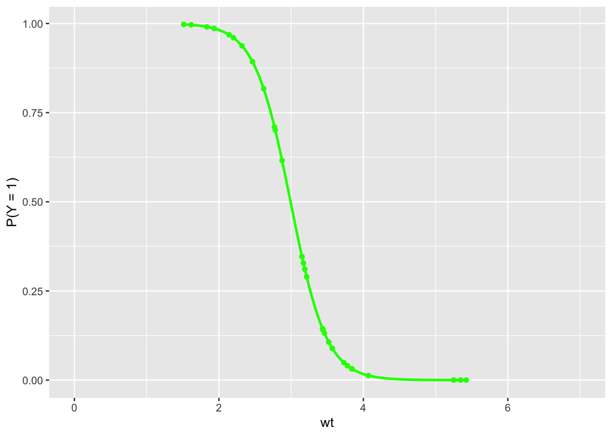

```r
ggplot(logistic_df, aes(x=wt, y=yhat_logistic))+
  geom_point(color="green")+
  stat_smooth(method="glm", se=FALSE, method.args = list(family=binomial), color="green")+
  xlim(c(0,7))+
  xlab("wt")+
  ylab("P(Y = 1)")
```

1. what’s the interpretation of the estimated $\hat{\beta}_0$ (the *Intercept*)

```r
logistic.model$coefficients[1]
```

```
## (Intercept)
##    12.04037
```

```r
inv.logit(logistic.model$coefficients[1])
```

```
## (Intercept)
##   0.9999941
```

**The intercept is 12.04, which is not easily interpretable, since it’s on the log-scale. By using the inv.logit function, the numbers are converted into probabilities, which tell us that there is a 99.99% probability that a car has manual transmission if the weight is 0 (which is just a hypothetical scenario, since a car can’t have weight 0).**

2. calculate the estimated probability that the Pontiac Firebird has automatic transmission, given its weight

```r
inv.logit(logistic.model$coefficients[1] + logistic.model$coefficients[2]*3.845)
```

```
## (Intercept)
##  0.03131644
```

3. bonus question - plot the logistic function and highlight all the cars where we guessed wrongly, if we used the following “quantizer” function:

$$\begin{equation}
transmission_{guess}=
\begin{cases}
1 (manual), & \text{if}\ PR(y = 1) ≥ 0.5 \\
0 (automatic), & \text{otherwise}
\end{cases}
\end{equation}$$

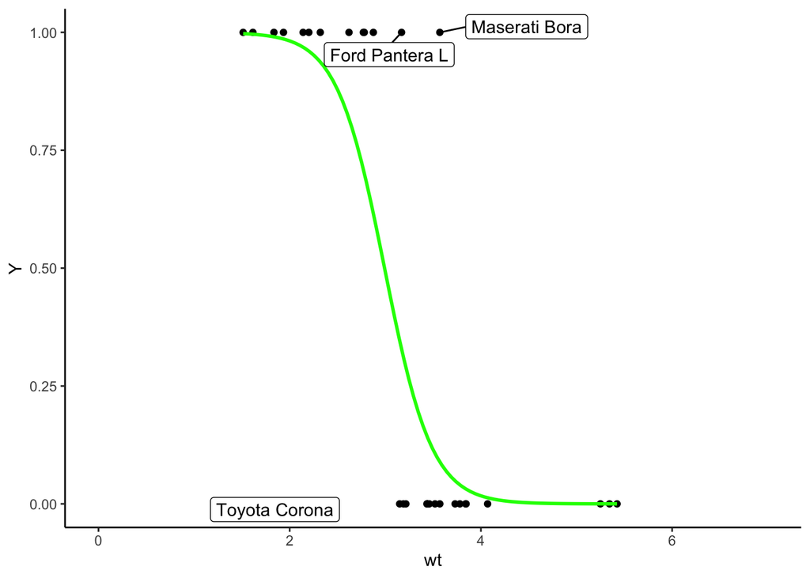

```r
names <- rownames(mtcars)
logistic_df <- cbind(logistic_df, names)
pacman::p_load("ggrepel")

# creating a new column where the the predicted probabilites above 0.5 get label "1" and below get 0
logistic_df$predicted <- ifelse(yhat_logistic>0.5,1,0)

#plotting the logistic funtion and highlighting those were we guessed wrongly
mtcars_plot <- ggplot(logistic_df, aes(x = wt, y = am))+
  geom_point()+
  stat_smooth(method="glm", se=FALSE, method.args = list(family=binomial), color="green")+
  geom_label_repel(aes(label=ifelse(am != predicted, names, '')), hjust=0,vjust=0)+
  xlim(c(0,7))+
  theme_classic()+
  xlab("wt")+
  ylab("Y")
mtcars_plot
```

3. plot quadratic fit alongside linear fit

```r
mtcars$quadratic <- (mtcars$wt)^2

quadr_fit <- glm(am ~ wt + quadratic, data=mtcars, family='binomial')
summary(quadr_fit)
```

```
##
## Call:
## glm(formula = am ~ wt + quadratic, family = "binomial", data = mtcars)
##
## Deviance Residuals:
##      Min        1Q    Median        3Q       Max
## -2.10096  -0.52927  -0.06135   0.29643   2.24318
##
## Coefficients:
##             Estimate Std. Error z value Pr(>|z|)
## (Intercept)   7.0791    19.7641   0.358    0.720
## wt           -0.5955    13.6211  -0.044    0.965
## quadratic    -0.5794     2.3222  -0.250    0.803
##
## (Dispersion parameter for binomial family taken to be 1)
##
##     Null deviance: 43.230  on 31  degrees of freedom
## Residual deviance: 19.118  on 29  degrees of freedom
## AIC: 25.118
##
## Number of Fisher Scoring iterations: 7
```

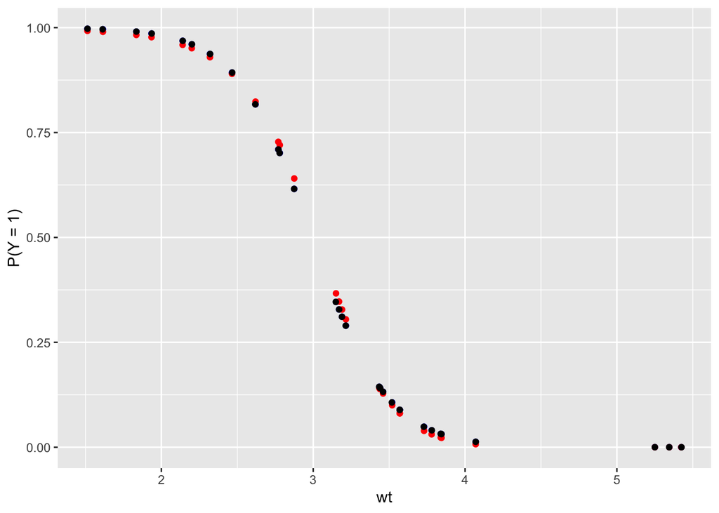

```r
yhat_quadr <- inv.logit(predict(quadr_fit))
logistic_df <- data.frame(cbind(logistic_df, yhat_quadr))

ggplot(logistic_df, aes(x=wt, y=yhat_logistic))+
  geom_point(color = "blue")+
  geom_point(y=yhat_quadr, color = "red")+
  geom_jitter()+
  xlab("wt")+
  ylab("P(Y = 1)")
```

1. judging visually, does adding a quadratic term make a difference? **- Not a lot - the predicted probabilites are almost the same**
2. check the details in the help of the AIC function - which of the models provide the better fit according to the AIC values and the residual deviance respectively?

```r
summary(logistic.model)
```

```
##
## Call:
## glm(formula = am ~ wt, family = "binomial", data = mtcars)
##
## Deviance Residuals:
##      Min        1Q    Median        3Q       Max
## -2.11400  -0.53738  -0.08811   0.26055   2.19931
##
## Coefficients:
##             Estimate Std. Error z value Pr(>|z|)
## (Intercept)   12.040      4.510   2.670  0.00759 **
## wt            -4.024      1.436  -2.801  0.00509 **
## ---
## Signif. codes:  0 '***' 0.001 '**' 0.01 '*' 0.05 '.' 0.1 ' ' 1
##
## (Dispersion parameter for binomial family taken to be 1)
##
##     Null deviance: 43.230  on 31  degrees of freedom
## Residual deviance: 19.176  on 30  degrees of freedom
## AIC: 23.176
##
## Number of Fisher Scoring iterations: 6
```

```r
#residual deviance is 19.176

summary(quadr_fit)
```

```
##
## Call:
## glm(formula = am ~ wt + quadratic, family = "binomial", data = mtcars)
##
## Deviance Residuals:
##      Min        1Q    Median        3Q       Max
## -2.10096  -0.52927  -0.06135   0.29643   2.24318
##
## Coefficients:
##             Estimate Std. Error z value Pr(>|z|)
## (Intercept)   7.0791    19.7641   0.358    0.720
## wt           -0.5955    13.6211  -0.044    0.965
## quadratic    -0.5794     2.3222  -0.250    0.803
##
## (Dispersion parameter for binomial family taken to be 1)
##
##     Null deviance: 43.230  on 31  degrees of freedom
## Residual deviance: 19.118  on 29  degrees of freedom
## AIC: 25.118
##
## Number of Fisher Scoring iterations: 7
```

```r
#residual deviance is 19.118

AIC(logistic.model, quadr_fit)
```

```
##                df      AIC
## logistic.model  2 23.17608
## quadr_fit       3 25.11779
```

**- the logistic model has the lower AIC, thus providing the better fit. The residual deviance is a bit lower that the quadratic fit - but not a lot. This means that the quadratic term does not improve the model very much.**

3. in your own words, why might it be good to penalise a model like the quadratic model, we just fitted.

**It’s a good idea to penalise models in order to avoid overfitting. If a model is overfitted, it’s hard to generalize it, and thus it will perform badly on new data, it hasn’t seen before (because it has been to ‘specialized’ on the original data). Models that get too complex are penalized more than simpler models, in order to take the risk of overfitting into account.**